# Activity Monitoring

salimt

5/17/2020

## Activity Monitoring Data Analysis

The data for this assignment can be downloaded from the course web site:

- **Dataset:** Activity monitoring data [52K] The variables included in this dataset are:
- **steps:** Number of steps taking in a 5-minute interval (missing values are coded as NA)
- **date:** The date on which the measurement was taken in YYYY-MM-DD format
- **interval**: Identifier for the 5-minute interval in which measurement was taken

The dataset is stored in a comma-separated-value (CSV) file and there are a total of 17,568 observations in this dataset.

```r
# Import the data and look at the first six rows
data1 <- read.csv(file = 'activity.csv')
data <- na.omit(data1)
data$date <- as.Date(data$date)
data <- subset(data, steps != 0)
head(data)
```

```
##     steps       date interval
## 555   117 2012-10-02     2210
## 556     9 2012-10-02     2215
## 627     4 2012-10-03      410
## 631    36 2012-10-03      430
## 644    25 2012-10-03      535
## 647    90 2012-10-03      550
```

### What is mean total number of steps taken per day?

For this part of the assignment, you can ignore the missing values in the dataset.

1. Calculate the total number of steps taken per day

```r
totalNumOfSteps <- colSums(data['steps'], na.rm=TRUE)
totalNumOfSteps
```

```
##  steps
## 570608
```

2. Make a histogram of the total number of steps taken each day

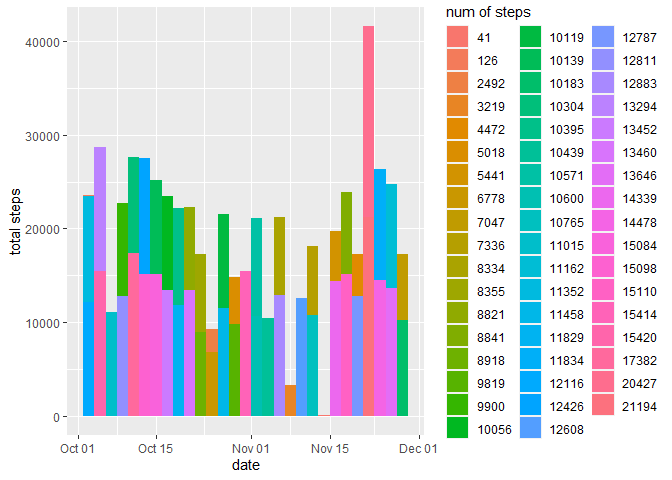

```r
library("ggplot2")
library("scales")
eachDay <- aggregate(steps ~ date, data = data, FUN = sum)

ggplot(eachDay) +
        geom_histogram(aes(x=date, weight=steps, fill=factor(steps))) +
        ylab("total steps") +
        scale_fill_discrete(name = "num of steps")
```

3. Calculate and report the mean and median of the total number of steps taken per day

```r
library(doBy)
info <- summaryBy(steps ~ date, data = data,
                  FUN = list(mean, median, sum), na.rm=TRUE)
info
```

```
##          date steps.mean steps.median steps.sum
## 1  2012-10-02   63.00000         63.0       126
## 2  2012-10-03  140.14815         61.0     11352
## 3  2012-10-04  121.16000         56.5     12116
## 4  2012-10-05  154.58140         66.0     13294
## 5  2012-10-06  145.47170         67.0     15420
## 6  2012-10-07  101.99074         52.5     11015
## 7  2012-10-09  134.85263         48.0     12811
## 8  2012-10-10   95.19231         56.5      9900
## 9  2012-10-11  137.38667         35.0     10304
## 10 2012-10-12  156.59459         46.0     17382
## 11 2012-10-13  119.48077         45.5     12426
## 12 2012-10-14  160.61702         60.5     15098
## 13 2012-10-15  131.67532         54.0     10139
## 14 2012-10-16  157.12500         64.0     15084
```

[output cut: 39 more lines]

### What is the average daily activity pattern?

1. Make a time series plot (i.e. type = “l”) of the 5-minute interval (x-axis) and the average number of steps taken, averaged across all days (y-axis)

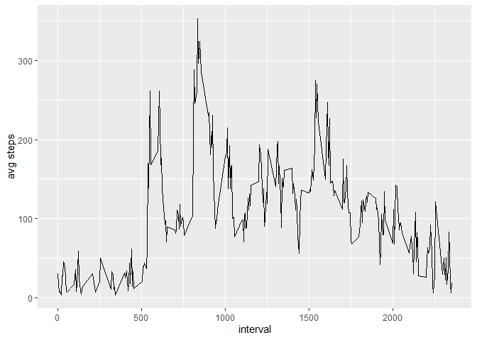

```r
timeSeries <- aggregate(steps ~ interval , data = data, FUN = mean)

ggplot(timeSeries) +
        geom_line(aes(x=interval, y=steps)) +
        ylab("avg steps") +
        xlab("interval")
```

2. Which 5-minute interval, on average across all the days in the dataset, contains the maximum number of steps?

```r
timeSeries[which.max(timeSeries$steps), ]
```

```
##    interval    steps
## 86      835 352.4839
```

### Imputing missing values

1. Calculate and report the total number of missing values in the dataset (i.e. the total number of rows with NAs)

```r
colSums(is.na(data1))
```

```
##    steps     date interval
##     2304        0        0
```

```r
idx <- which(is.na(data1$steps))

data1$steps[idx] <- timeSeries$steps[timeSeries$interval==data1$interval]

colSums(is.na(data1))
```

```
##    steps     date interval
##        0        0        0
```

3. Make a histogram of the total number of steps taken each day and Calculate and report the mean and median total number of steps taken per day. Do these values differ from the estimates from the first part of the assignment? What is the impact of imputing missing data on the estimates of the total daily number of steps?

```r
newInfo <- summaryBy(steps ~ date, data = data1,
                     FUN = list(mean, median, sum), na.rm=TRUE)
newInfo
```

```
##          date steps.mean steps.median steps.sum
## 1  2012-10-01 21.1354167       22.875      6087
## 2  2012-10-02  0.4375000        0.000       126
## 3  2012-10-03 39.4166667        0.000     11352
## 4  2012-10-04 42.0694444        0.000     12116
## 5  2012-10-05 46.1597222        0.000     13294
## 6  2012-10-06 53.5416667        0.000     15420
## 7  2012-10-07 38.2465278        0.000     11015
## 8  2012-10-08 21.1354167       22.875      6087
## 9  2012-10-09 44.4826389        0.000     12811
## 10 2012-10-10 34.3750000        0.000      9900
## 11 2012-10-11 35.7777778        0.000     10304
## 12 2012-10-12 60.3541667        0.000     17382
## 13 2012-10-13 43.1458333        0.000     12426
## 14 2012-10-14 52.4236111        0.000     15098
```

[output cut: 47 more lines]

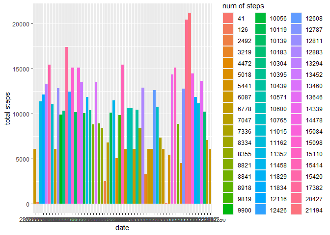

```r
newEachDay <- aggregate(steps ~ date, data = data1, FUN = sum)

ggplot(newEachDay) +
        geom_histogram(aes(x=date, weight=steps, fill=factor(steps)), stat = "count")         + ylab("total steps") +
        scale_fill_discrete(name = "num of steps")
```

### Are there differences in activity patterns between weekdays and weekends?

1. Create a new factor variable in the dataset with two levels – “weekday” and “weekend” indicating whether a given date is a weekday or weekend day.

```r
data1$date <- as.Date(data1$date)
data1$week <- ifelse(weekdays(data1$date) %in% c("Saturday", "Sunday"), "weekend", "weekday")
head(data1)
```

```
##      steps       date interval    week
## 1 30.33333 2012-10-01        0 weekday
## 2 18.00000 2012-10-01        5 weekday
## 3  7.00000 2012-10-01       10 weekday
## 4  8.00000 2012-10-01       15 weekday
## 5  4.00000 2012-10-01       20 weekday
## 6 27.75000 2012-10-01       25 weekday
```

2. Make a panel plot containing a time series plot (i.e. type = “l”) of the 5-minute interval (x-axis) and the average number of steps taken, averaged across all weekday days or weekend days (y-axis). See the README file in the GitHub repository to see an example of what this plot should look like using simulated data.

```r
library(data.table)
newTimeSeries <- data.table(data1)
meanByInterval <- newTimeSeries[, mean(steps), by=list(interval, week)]
meanByInterval
```

```
##      interval    week         V1
##   1:        0 weekday  6.0666667
##   2:        5 weekday  2.8000000
##   3:       10 weekday  1.0888889
##   4:       15 weekday  1.2444444
##   5:       20 weekday  0.6222222
##  ---
## 572:     2335 weekend 12.0000000
## 573:     2340 weekend  6.3750000
## 574:     2345 weekend  5.0937500
## 575:     2350 weekend  3.5000000
## 576:     2355 weekend  5.7500000
```

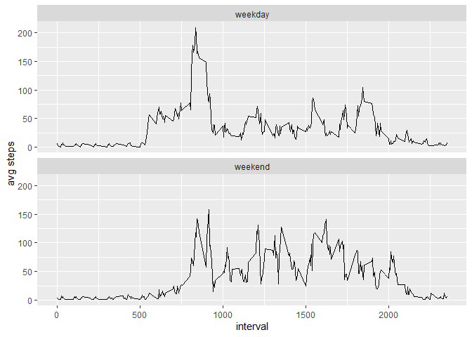

```r
ggplot(meanByInterval) +
        geom_line(aes(x=interval, y=V1)) +
        ylab("avg steps") +
        xlab("interval") +
        facet_wrap(~ week, ncol=1)
```